# Generalized Linear Models

Tarek El-Hajjaoui

2023-04-23

## AirBnB

### Q 4.11.3.1 Airbnb in NYC

Perform an EDA, build a model, and interpret model coefficients to describe variation in the number of reviews (a proxy for the number of rentals, which is not available) as a function of the variables provided. Don’t forget to consider an offset, if needed.

```r
# Loading the dataset
file_path = './NYCairbnb.csv'
df = read.csv(file_path, header = TRUE)
```

```r
# View dataframe summary
str(df)
```

```
## 'data.frame':    40628 obs. of  13 variables:
##  $ id                       : int  2515 2595 3647 3831 4611 5099 5107 5121 5172 5178 ...
##  $ days                     : int  3130 3127 3050 3038 3012 2981 2981 2980 2980 2952 ...
##  $ last_scraped             : chr  "4/2/2017" "4/2/2017" "4/2/2017" "4/2/2017" ...
##  $ host_since               : chr  "9/6/2008" "9/9/2008" "11/25/2008" "12/7/2008" ...
##  $ room_type                : chr  "Private room" "Entire home/apt" "Private room" "Entire home/apt" ...
##  $ bathrooms                : num  1 1 1 1 NA 1 1 NA 1 1 ...
##  $ bedrooms                 : int  1 0 1 1 1 1 2 1 1 1 ...
##  $ price                    : int  59 230 150 89 39 212 250 60 129 79 ...
##  $ number_of_reviews        : int  150 20 0 116 93 60 60 50 53 329 ...
##  $ review_scores_cleanliness: int  9 9 NA 9 9 9 10 8 9 7 ...
##  $ review_scores_location   : int  9 10 NA 9 8 9 9 9 10 10 ...
##  $ review_scores_value      : int  9 9 NA 9 9 9 10 9 9 9 ...
##  $ instant_bookable         : chr  "f" "f" "f" "f" ...
```

#### Q 4.11.3.1 Airbnb in NYC - Explanatory Data Analysis (EDA)

Preprocessing - transforming data types

```r
# Transforming categorical columns to factor data type.
categorical_cols <- c('room_type', 'bathrooms', 'bedrooms', 'review_scores_cleanliness', 'review_scores_location', 'review_scores_value', 'instant_bookable')
df[categorical_cols] <- lapply(df[categorical_cols], as.factor)

# Transforming date columns
date_cols <- c('last_scraped', 'host_since')
df[date_cols] <- lapply(df[date_cols], as.Date)
```

**Checking if the data justifies a Poisson regression model.**

Plotting the $Y$, number of reviews.

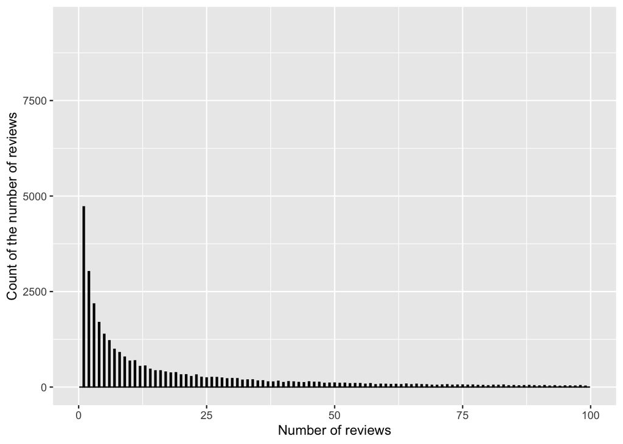

```r
ggplot(df, aes(number_of_reviews)) +
  geom_histogram(binwidth = .25, color = "black", fill = "white") +
  xlim(0, 100) +
  xlab("Number of reviews") +
  ylab("Count of the number of reviews")
```

```r
max(df[['number_of_reviews']])
```

```
## [1] 421
```

**Note:** X-axis has been condensed for visual reasons, however, there are some (not many) AirBnB observations with number of reviews ranging from 100-421.

- Number of reviews appears to follow a Poisson distribution given by the right-skewed histogram above. As the number of reviews increases, the count of the number of reviews decreases.

Checking for the assumption of $\mu = \sigma^2$ (mean = variance).

Compare mean and variance of the number of reviews for the review score cleaniness groups.

| review_scores_cleanliness | Mean | Variance | n |
| --- | --- | --- | --- |
| 2 | 1.2649573 | 0.4033304 | 117 |
| 3 | 3.5555556 | 7.0277778 | 9 |
| 4 | 1.6267606 | 1.6823994 | 142 |
| 5 | 4.6506024 | 15.3764326 | 83 |
| 6 | 4.6682243 | 141.7321869 | 642 |
| 7 | 14.7849224 | 746.7550221 | 902 |
| 8 | 19.5222705 | 1054.8945052 | 3682 |
| 9 | 29.9669195 | 1333.1789709 | 9492 |
| 10 | 17.6759307 | 831.3170253 | 15364 |
| NA | 0.1113291 | 1.1723211 | 10195 |

Compare mean and variance of the number of reviews for the review score location groups.

| review_scores_location | Mean | Variance | n |
| --- | --- | --- | --- |
| 2 | 1.2727273 | 0.4935065 | 22 |
| 3 | 2.5000000 | 0.5000000 | 2 |
| 4 | 1.3333333 | 0.9166667 | 33 |
| 5 | 3.0000000 | 3.1000000 | 21 |
| 6 | 1.8741259 | 5.2893633 | 286 |
| 7 | 14.6930946 | 683.3158240 | 391 |
| 8 | 21.7378741 | 1204.9051136 | 2907 |
| 9 | 29.7634128 | 1339.2165498 | 9189 |
| 10 | 17.2257604 | 807.0291572 | 17523 |
| NA | 0.1179052 | 1.1762852 | 10254 |

Compare mean and variance of the number of reviews for the review score value groups.

| review_scores_value | Mean | Variance | n |
| --- | --- | --- | --- |
| 2 | 1.2203390 | 0.4506137 | 59 |
| 3 | 4.0000000 | NA | 1 |
| 4 | 1.4285714 | 1.2117040 | 84 |
| 5 | 2.7692308 | 3.3400810 | 39 |
| 6 | 2.1878613 | 22.5008377 | 346 |
| 7 | 7.3429395 | 222.4803185 | 347 |
| 8 | 13.6347050 | 574.1705854 | 2576 |
| 9 | 32.5658989 | 1487.0664979 | 11548 |
| 10 | 14.9718319 | 656.2248912 | 15372 |
| NA | 0.1184672 | 1.1774805 | 10256 |

There is some evidence of a violation of the mean=variance assumption. It appears that the variance is smaller than the mean for lower number of reviews, while the variance is greater than the mean for higher number of reviews.

The Poisson regression model implies that log($\lambda_i$) is a linear function of feature variables; i.e., $log(\lambda_i)=\beta_0+\beta_i\textrm{feature}_i$. Therefore, to check the linearity assumption for Poisson regression, we would like to plot log($\lambda_i$) by $\beta_i$.

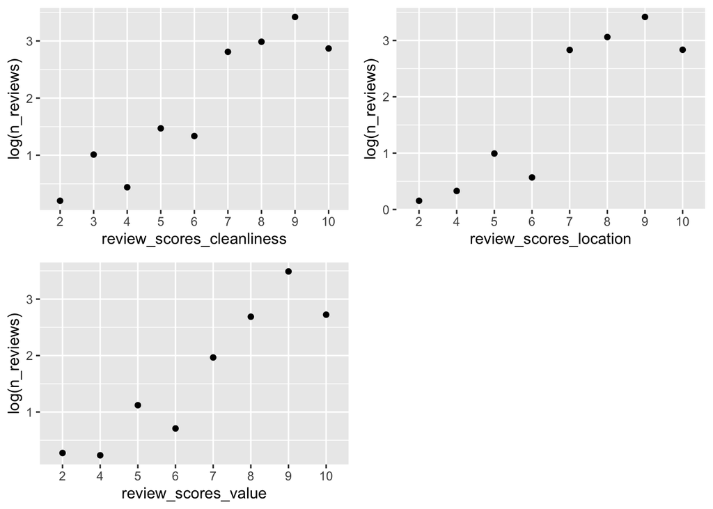

```r
# Remove rows where x is null
df_no_nulls <- df[complete.cases(df), ]

sumStats <- df_no_nulls %>% group_by(review_scores_cleanliness) %>%
  summarise(mn_reviews = mean(number_of_reviews),
            logmn_reviews = log(mn_reviews), n=n())

sumStats2 <- df_no_nulls %>% group_by(review_scores_location) %>%
  summarise(mn_reviews = mean(number_of_reviews),
            logmn_reviews = log(mn_reviews), n=n())

sumStats3 <- df_no_nulls %>% group_by(review_scores_value) %>%
  summarise(mn_reviews = mean(number_of_reviews),
            logmn_reviews = log(mn_reviews), n=n())

plot1 <- ggplot(sumStats, aes(x=review_scores_cleanliness, y=logmn_reviews)) +
  geom_point()+
  geom_smooth()+
  xlab("review_scores_cleanliness") +
  ylab("log(n_reviews)")

plot2 <- ggplot(sumStats2, aes(x=review_scores_location, y=logmn_reviews)) +
  geom_point()+
  geom_smooth()+
  xlab("review_scores_location") +
  ylab("log(n_reviews)")

plot3 <- ggplot(sumStats3, aes(x=review_scores_value, y=logmn_reviews)) +
  geom_point()+
  geom_smooth()+
  xlab("review_scores_value") +
  ylab("log(n_reviews)")

# Arrange the plots in a row using grid.arrange()
grid.arrange(plot1, plot2, plot3, ncol = 2)
```

#### Q 4.11.3.1 Airbnb in NYC - Offset

In general, when using a Poisson regression model, the variable to be offset should be a measure of exposure or effort. For this dataset, the variable to be offset would be a measure of the time that each rental unit is available for rent which is *days*.

Plotting $Y$, number of reviews against log(days).

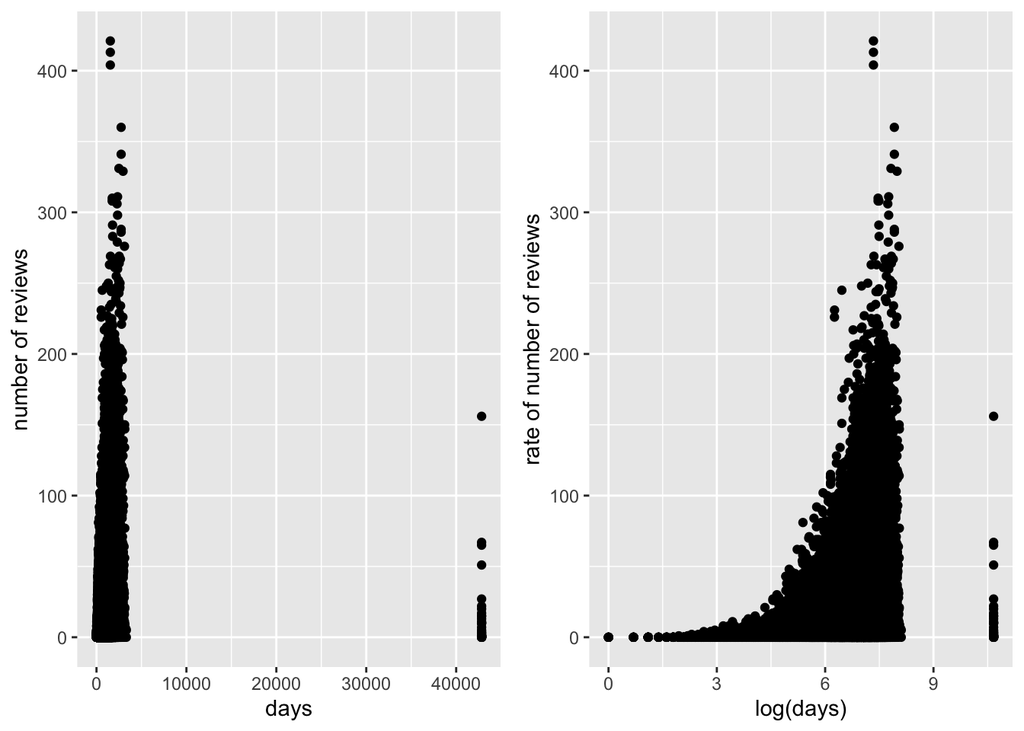

```r
p1 <- ggplot(df, aes(x = days, y = number_of_reviews)) +
  geom_point() +
  xlab("days") +
  ylab("number of reviews")

p2 <- ggplot(df, aes(x=log(days), y=number_of_reviews)) +
  geom_point() +
  xlab("log(days)") +
  ylab("rate of number of reviews")

# Arrange the plots in a row using grid.arrange()
grid.arrange(p1, p2, ncol = 2)
```

```r
# calculate correlation
cor(df$days, df$number_of_reviews)
```

```
## [1] 0.1036332
```

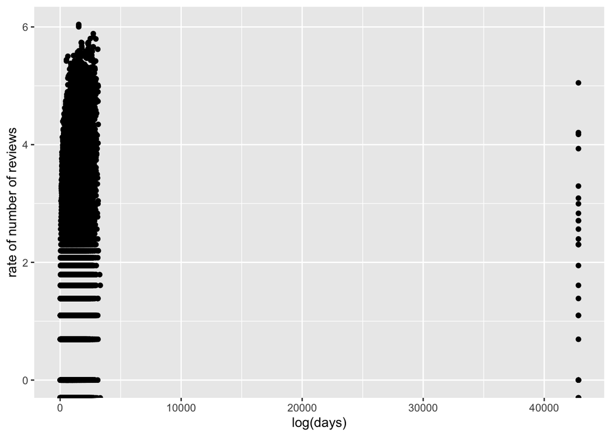

```r
ggplot(df, aes(x=days, y=log(number_of_reviews))) +
  geom_point() +
  xlab("log(days)") +
  ylab("rate of number of reviews")
```

The rate of increase in the number of reviews is exponential which suggets that log(days) may be needed to offset for the non-constant rate of number of reviews. The offset variable will be tested further in model building.

#### Q 4.11.3.1 Airbnb in NYC - Model Building

Creating 2 models with the same predictors, but the first reduced model does not contain an offset variable of log(days).

```r
no_offset_model <- glm(number_of_reviews ~ review_scores_cleanliness + review_scores_location + review_scores_value,
                     data = df, family = poisson)
full_poisson_model <- glm(number_of_reviews ~ review_scores_cleanliness + review_scores_location + review_scores_value + offset(log(days)),
                     data = df, family = poisson)
```

```r
# data frame to summarize model comparisons
model_stats_df <- data.frame(
  Model = c("No Offset", "Offset"),
  Residual_Deviance = c(deviance(no_offset_model),deviance(full_poisson_model)),
  AIC = c(AIC(no_offset_model), AIC(full_poisson_model)),
  BIC = c(BIC(no_offset_model), BIC(full_poisson_model))
)

model_stats_df
```

```
##       Model Residual_Deviance      AIC      BIC
## 1 No Offset          817058.2 939420.7 939628.7
## 2    Offset          868228.9 990591.4 990799.4
```

The model without the offset has lower residual deviances, AIC, and BIC which suggests the model with the offset is not a better fit for the data than the model without the offset. This is because the residual deviance measures the lack of fit of the model to the data, and AIC/BIC provides a measure of the quality of the model in terms of goodness of fit and parsimony. A higher residual deviance and AIC both suggest a worse model fit, thus the model without offset will be used.

#### Q 4.11.3.1 Airbnb in NYC - Coefficient Interpretation

```r
# Obtaining coefficient estimates
coef_estimates <- coef(no_offset_model)

# Exponentiating coefficients to be able to interpret coefficients
# Because exponentiating the coefficient allows us
# to obtain the multiplicative factor by which the mean count changes
exp_coef <- exp(coef_estimates)
round(exp_coef, 4)
```

```
##                 (Intercept)  review_scores_cleanliness3
##                      0.8312                      1.4279
##  review_scores_cleanliness4  review_scores_cleanliness5
##                      0.7636                      1.4176
##  review_scores_cleanliness6  review_scores_cleanliness7
##                      1.4063                      2.7146
##  review_scores_cleanliness8  review_scores_cleanliness9
##                      3.2629                      4.3970
## review_scores_cleanliness10     review_scores_location3
##                      3.6413                      0.7460
##     review_scores_location4     review_scores_location5
##                      0.3854                      0.4146
##     review_scores_location6     review_scores_location7
##                      0.2717                      1.2499
##     review_scores_location8     review_scores_location9
##                      1.4741                      1.7418
##    review_scores_location10        review_scores_value3
##                      1.2213                     11.6080
##        review_scores_value4        review_scores_value5
##                      1.1557                      1.5975
##        review_scores_value6        review_scores_value7
##                      1.1564                      2.3266
##        review_scores_value8        review_scores_value9
##                      3.5762                      6.7350
##       review_scores_value10
##                      3.5965
```

Because we are working with categorical features (review_scores_cleanliness, review_scores_location, review_scores_values) each of their factors are considered a covariate in the Poisson models. Each coefficient was exponentiated to be able to interpret coefficients, which allows us to obtain the multiplicative factor by which the mean count changes. Some of the interpretations are translated below.

- *review_scores_cleanliness4*: the expected the response variable ($\lambda$ = estimated mean number of reviews) would decrease by a factor of approximately 0.7636 holding all other variables constant.
- *review_scores_location8*: the expected the response variable ($\lambda$ = estimated mean number of reviews) would increase by a factor of approximately 1.4741 holding all other variables constant.
- *review_scores_value9*: the expected the response variable ($\lambda$ = estimated mean number of reviews) would increase by a factor of approximately 6.7350 holding all other variables constant.

### Q 5.4.1

#### Q 5.4.1.g

Gamma (for fixed r): Y = time spent waiting for the rth event in a Poisson process with an average rate of $\lambda$ events per unit of time

1. Write the pmf or pdf in one-parameter exponential form, if possible.

$$e^{log(y)r -
rlog(\lambda)exp(\frac{-y}{\lambda})}$$
b. Describe an example of a setting where this random variable might be used.

Modeling the time between successive arrivals of customers at a store. A Poisson process to model the arrival of customers, where $\lambda$ is the average number of customers that arrive in a unit of time. The random variable y would be the time that a customer spends in the line before being served, which follows the gamma distribution with parameters r and $\lambda$.

3. Identify the canonical link function.
- $a(y) = log(y)$
- $b(\lambda) = r$
- $c(\lambda) = rlog(\lambda)$
- $d(y) = exp(\frac{-y}{\lambda})$
4. Compute $\mu$ and $\sigma^2$, then compare with E(Y) and E(Y).
- $E(Y) = \frac{-\frac{r}{\lambda}}{1} \Rightarrow -\frac{r}{\lambda}$
- $\mu =\frac{r}{\lambda}$
- $Var(Y) = \frac{0 * \frac{r}{\lambda} - \frac{-r}{\lambda^2}}{1^2} \Rightarrow \frac{r}{\lambda^2}$
- $\sigma^2 =\frac{r}{\lambda^2}$

#### Q 5.4.1.i

1. Write the pmf or pdf in one-parameter exponential form, if possible.

$$e^{ylog(1-p) + rlog(p) +
log(\frac{\Gamma(y+r)}{\Gamma(r)})}$$

2. Describe an example of a setting where this random variable might be used.

Can be used in sports analytics to model the number of games a team needs to win before reaching a certain number of losses. Each game has a probability of a win, p.

3. Identify the canonical link function.
- $a(y) = y$
- $b(p) = log(1-p)$
- $c(p) = rlog(p)$
- $d(y) = log(\frac{\Gamma(y+r)}{\Gamma(r)})$
4. Compute $\mu$ and $\sigma^2$, then compare with E(Y) and E(Y).
- $E(Y) = \frac{-\frac{r}{p}}{\frac{1}{1-p}} \Rightarrow \frac{r(1-p)}{p}$
- $\mu =\frac{r(1-p)}{p}$
- $Var(Y) = \frac{\frac{r}{p(1-p)^2} - \frac{r}{p^2(1-p)}}{(-\frac{1}{1-p})^3} \Rightarrow \frac{r(1-p)}{p^2}$
- $\sigma^2 =\frac{r(1-p)}{p^2}$

### Q 6.8.1.1

List the explanatory and response variable(s) for each research question.

#### Q 6.8.1.1 a

Are students with poor grades more likely to binge drink?

- Explanatory Variable: Poor grades.
- Response Variable: Binge drinker (binary).

#### Q 6.8.1.1 b

What is the chance you are accepted into medical school given your GPA and MCAT scores?

- Explanatory Variable: GPA, MCAT Score.
- Response Variable: Accepted to Medical School (binary).

#### Q 6.8.1.1 c

Is a single mom more likely to marry the baby’s father if she has a boy?

- Explanatory Variable: Baby’s gender.
- Response Variable: Marry the baby’s father (binary).

#### Q 6.8.1.1 d

Are students participating in sports in college more or less likely to graduate?

- Explanatory Variable: Participation in sports in college.
- Response Variable: Graduate (binary).

#### Q 6.8.1.1 e

Is exposure to a particular chemical associated with a cancer diagnosis?

- Explanatory Variable: Exposure to particular chemical.
- Response Variable: Diagnosed with Cancer (binary).

### Q 6.8.2.2

Medical school admissions.

```r
df_med <- read.csv('./MedGPA.csv')
str(df_med)
```

```
## 'data.frame':    55 obs. of  11 variables:
##  $ Accept    : chr  "D" "A" "A" "A" ...
##  $ Acceptance: int  0 1 1 1 1 1 1 0 1 1 ...
##  $ Sex       : chr  "F" "M" "F" "F" ...
##  $ BCPM      : num  3.59 3.75 3.24 3.74 3.53 3.59 3.85 3.26 3.74 3.86 ...
##  $ GPA       : num  3.62 3.84 3.23 3.69 3.38 3.72 3.89 3.34 3.71 3.89 ...
##  $ VR        : int  11 12 9 12 9 10 11 11 8 9 ...
##  $ PS        : int  9 13 10 11 11 9 12 11 10 9 ...
##  $ WS        : int  9 8 5 7 4 7 6 8 6 6 ...
##  $ BS        : int  9 12 9 10 11 10 11 9 11 10 ...
##  $ MCAT      : int  38 45 33 40 35 36 40 39 35 34 ...
##  $ Apps      : int  5 3 19 5 11 5 5 7 5 11 ...
```

```r
categorical_cols <- c('Accept', 'Acceptance', 'Sex')
df_med[categorical_cols] <- lapply(df_med[categorical_cols], as.factor)
```

#### Q 6.8.2.2 a

Compare the relative effects of improving your MCAT score versus improving your GPA on your odds of being accepted to medical school.

```r
# Group by Acceptance and show 5 number summary for MCAT & GPA
by(df_med[, c("MCAT", "GPA")], df_med$Acceptance, summary)
```

```
## df_med$Acceptance: 0
##       MCAT            GPA
##  Min.   :18.00   Min.   :2.720
##  1st Qu.:32.00   1st Qu.:3.290
##  Median :34.00   Median :3.380
##  Mean   :34.12   Mean   :3.385
##  3rd Qu.:37.00   3rd Qu.:3.610
##  Max.   :41.00   Max.   :3.770
## ------------------------------------------------------------
## df_med$Acceptance: 1
##       MCAT            GPA
##  Min.   :31.00   Min.   :3.140
##  1st Qu.:35.00   1st Qu.:3.545
##  Median :38.50   Median :3.715
##  Mean   :38.07   Mean   :3.693
##  3rd Qu.:40.00   3rd Qu.:3.888
##  Max.   :48.00   Max.   :3.970
```

```r
# Fit a logistic regression model with both MCAT score and GPA as predictors
model <- glm(Acceptance ~ MCAT + GPA, data = df_med, family = binomial)

# View the model summary
summary(model)
```

```
##
## Call:
## glm(formula = Acceptance ~ MCAT + GPA, family = binomial, data = df_med)
##
## Deviance Residuals:
##     Min       1Q   Median       3Q      Max
## -1.7132  -0.8132   0.3136   0.7663   1.9933
##
## Coefficients:
##             Estimate Std. Error z value Pr(>|z|)
## (Intercept) -22.3727     6.4538  -3.467 0.000527 ***
## MCAT          0.1645     0.1032   1.595 0.110786
## GPA           4.6765     1.6416   2.849 0.004389 **
## ---
## Signif. codes:  0 '***' 0.001 '**' 0.01 '*' 0.05 '.' 0.1 ' ' 1
##
## (Dispersion parameter for binomial family taken to be 1)
##
##     Null deviance: 75.791  on 54  degrees of freedom
## Residual deviance: 54.014  on 52  degrees of freedom
## AIC: 60.014
##
## Number of Fisher Scoring iterations: 5
```

```r
# Exponentiate the coefficients
round(exp(coef(model)), 4)
```

```
## (Intercept)        MCAT         GPA
##      0.0000      1.1788    107.3891
```

```r
round(exp(confint(model, level=0.95)), 4)
```

```
##              2.5 %    97.5 %
## (Intercept) 0.0000    0.0000
## MCAT        0.9743    1.4672
## GPA         5.6895 3913.2832
```

The above logistic regression model uses GPA and MCAT as its features for predicting acceptance of medical school.

- The odds of getting accepted to medical school for one unit increase in GPA are 107.389 times the odds for a one unit decrease in GPA, holding all other predictor variables constant
- The odds of getting accepted to medical school for one unit increase in MCAT score are 1.1788 times the odds for a one unit decrease in MCAT, holding all other predictor variables constant.
- Both predictors have a positive association with getting accepted to medical school, however, GPA’s odds ratio is 100x larger than MCAT Score, thus it is much stronger predictor according to this model.

#### Q 6.8.2.2 b

After controlling for MCAT and GPA, is the number of applications related to odds of getting into medical school?

```r
# add Apps
model2 <- glm(Acceptance ~ MCAT + GPA + Apps, data = df_med, family = binomial)

summary(model2)
```

```
##
## Call:
## glm(formula = Acceptance ~ MCAT + GPA + Apps, family = binomial,
##     data = df_med)
##
## Deviance Residuals:
##     Min       1Q   Median       3Q      Max
## -1.6949  -0.8309   0.2900   0.7926   1.8238
##
## Coefficients:
##              Estimate Std. Error z value Pr(>|z|)
## (Intercept) -23.68942    7.02387  -3.373 0.000744 ***
## MCAT          0.17287    0.10537   1.641 0.100867
## GPA           4.86062    1.69441   2.869 0.004123 **
## Apps          0.04379    0.07617   0.575 0.565412
## ---
## Signif. codes:  0 '***' 0.001 '**' 0.01 '*' 0.05 '.' 0.1 ' ' 1
##
## (Dispersion parameter for binomial family taken to be 1)
##
##     Null deviance: 75.791  on 54  degrees of freedom
## Residual deviance: 53.682  on 51  degrees of freedom
## AIC: 61.682
##
## Number of Fisher Scoring iterations: 5
```

```r
round(exp(coef(model2)), 4)
```

```
## (Intercept)        MCAT         GPA        Apps
##      0.0000      1.1887    129.1036      1.0448
```

```r
round(exp(confint(model2)), 4)
```

```
##              2.5 %    97.5 %
## (Intercept) 0.0000    0.0000
## MCAT        0.9795    1.4886
## GPA         6.2888 5302.5174
## Apps        0.8993    1.2190
```

The odds of getting accepted to medical school for one unit increase in number of applications are 1.0448 times the odds for a one unit decrease in number of applications, holding all other predictor variables constant. In other words, number of applications seems to be unrelated or there is little evidence that it is related to being accepted to medical school.

Confidence Interval

- We are 95% confident that the interval (0.8993, 1.2190) contains the true value odds ratio of number of applications in relation to getting accepted in medical school.

#### Q 6.8.2.2 c

Is one MCAT subscale more important than the others?

```r
# Remove overall MCAT and replace with subscore features
model3 <- glm(Acceptance ~ GPA  + BCPM + VR + PS + WS + BS, data = df_med, family = binomial)

summary(model3)
```

```
##
## Call:
## glm(formula = Acceptance ~ GPA + BCPM + VR + PS + WS + BS, family = binomial,
##     data = df_med)
##
## Deviance Residuals:
##      Min        1Q    Median        3Q       Max
## -2.25870  -0.57854   0.01429   0.39682   1.91509
##
## Coefficients:
##             Estimate Std. Error z value Pr(>|z|)
## (Intercept) -44.6420    13.0578  -3.419 0.000629 ***
## GPA          13.6910     6.7445   2.030 0.042362 *
## BCPM         -7.4050     5.4541  -1.358 0.174561
## VR            0.2870     0.2557   1.122 0.261774
## PS            0.9088     0.4237   2.145 0.031971 *
## WS           -0.8164     0.3849  -2.121 0.033913 *
## BS            1.6849     0.6007   2.805 0.005031 **
## ---
## Signif. codes:  0 '***' 0.001 '**' 0.01 '*' 0.05 '.' 0.1 ' ' 1
##
## (Dispersion parameter for binomial family taken to be 1)
##
##     Null deviance: 74.192  on 53  degrees of freedom
## Residual deviance: 35.504  on 47  degrees of freedom
##   (1 observation deleted due to missingness)
## AIC: 49.504
##
## Number of Fisher Scoring iterations: 7
```

```r
round(exp(coef(model3)), 4)
```

```
## (Intercept)         GPA        BCPM          VR          PS          WS
##      0.0000 882960.7663      0.0006      1.3324      2.4813      0.4420
##          BS
##      5.3917
```

```r
round(exp(confint(model3)), 4)
```

```
##              2.5 %       97.5 %
## (Intercept) 0.0000 0.000000e+00
## GPA         4.6670 3.452966e+12
## BCPM        0.0000 1.642790e+01
## VR          0.8261 2.323500e+00
## PS          1.1594 6.422200e+00
## WS          0.1747 8.455000e-01
## BS          1.9540 2.256040e+01
```

Yes BS, biological subscale is by far the most important according to this model because odds of getting accepted to medical school for one unit increase in BS are 5.3917 times the odds for a one unit decrease in BS. The next highest odd ratio is PS.

In order of importance 1. BS (Biological sciences) 2. PS (Physical sciences) 3. VR (Verbal Reasoning)

Confidence Interval

- We are 95% confident that the interval (1.9540, 22.56040) contains the true value odds ratio of BS in relation to getting accepted in medical school.

#### Q 6.8.2.2 d

Is there any evidence that the effect of MCAT score or GPA differs for males and females?

```r
reduced_model <- glm(Acceptance ~ MCAT + GPA + Sex, data = df_med, family = binomial)
full_model <- glm(Acceptance ~ MCAT*Sex + GPA*Sex + Sex, data = df_med, family = binomial)
# anova test
anova_res <- anova(reduced_model, full_model, test = "Chisq")
# View the model summary
anova_res
```

```
## Analysis of Deviance Table
##
## Model 1: Acceptance ~ MCAT + GPA + Sex
## Model 2: Acceptance ~ MCAT * Sex + GPA * Sex + Sex
##   Resid. Df Resid. Dev Df Deviance Pr(>Chi)
## 1        51     50.786
## 2        49     48.627  2   2.1596   0.3397
```

The full model above contains interaction terms to test if the affect of MCAT and GPA are influenced by gender. The anova test was performed and the full model has a p-value of 0.3397 At a 5% significance level (ɑ), we accept the null hypothesis because the p-value is greater than 0.05. We can conclude evidence that the reduced model is good enough, and that MCAT and GPA do not differ for males and females.